# Exploratory data analysis and quality control of TCGA-BRCA RNA-seq data

Training set

Group 2: Multiomics - Parniyan, Sergi, Baizhen, Paula, Yueling

11 November 2026

# 1 Overview

This report documents the exploratory data analysis (EDA) and quality control (QC) of the **RNA-seq data of the TCGA-BRCA training set**. The aim is to understand the structure of the data, remove uninformative genes, detect atypical patients and identify technical factors that must be considered in the models (PCA, multi-omics integration, machine learning).

**Data**

- Input: `data/data_split/rna.train.rds`, with one row per patient and one column per gene, and the clinical data `clin.train.rds`.
- Values: RSEM gene-level counts transformed as **log2(CPM + 1)** in `01_data_preparation.R`. CPM corrects for sequencing depth using only each sample’s own total, so it was safe to compute before the train/test split.
- Output (written by `02_qc_rnaseq.R`): the filtered genes (`rna.train.filtered.rds`) and the QC parameters (`rna_qc_params.rds`), used to apply exactly the same filter to the test set.

All decisions are made on the training set only. This report does not overwrite any file (the saving step is shown but not run). Knit it from the project root with `rmarkdown::render("01_data_preprocess/02_qc_rnaseq.Rmd")`.

# 2 Setup

Packages, a common plot theme and two helper functions used in the report.

```r
library(matrixStats)   # fast row/column statistics on matrices
library(ggplot2)
```

```r
theme_qc <- function(base_size = 12) {
  theme_classic(base_size = base_size) +
    theme(plot.title    = element_text(face = "bold"),
          plot.subtitle = element_text(colour = "grey40", size = 9),
          legend.position = "top")
}
```

The barplot helper groups the proportion of zeros in bins (green = no zeros, blue = some zeros, red = mostly zeros).

```r
plot_zero_bins <- function(zero_frac, title, x_lab, step = 0.05, max_frac = 1) {
  upper  <- seq(step, max_frac, by = step)
  breaks <- c(-Inf, 0, upper, if (max_frac < 1) Inf)
  labels <- c("0%", paste0(round(100 * (upper - step)), "-", round(100 * upper), "%"),
              if (max_frac < 1) paste0("> ", round(100 * max_frac), "%"))
  df <- as.data.frame(table(bin = cut(zero_frac, breaks = breaks, labels = labels)))
  df$pct <- df$Freq / sum(df$Freq)

  n_bins   <- nrow(df)
  high_lab <- if (max_frac < 1) paste0("> ", round(100 * max_frac), "% zeros") else "> 90% zeros"
  is_high  <- if (max_frac < 1) seq_len(n_bins) == n_bins else c(0, upper) > 0.9
  df$group <- factor(ifelse(seq_len(n_bins) == 1, "No zeros",
                            ifelse(is_high, high_lab, "Some zeros")),
                     levels = c("No zeros", "Some zeros", high_lab))

  ggplot(df, aes(bin, Freq, fill = group)) +
    geom_col(width = 0.8) +
    geom_text(data = subset(df, Freq > 0),
              aes(label = sprintf("%d\n(%.0f%%)", Freq, 100 * pct)),
              vjust = -0.2, size = 2.6, lineheight = 0.85) +
    scale_fill_manual(values = c("#1A9850", "#2C7FB8", "#D73027"), name = NULL, drop = FALSE) +
    scale_y_continuous(expand = expansion(mult = c(0, 0.18))) +
    labs(title = title, subtitle = sprintf("n = %d", length(zero_frac)),
         x = x_lab, y = "Count") +
    theme_qc() +
    theme(axis.text.x = element_text(angle = 45, hjust = 1))
}
```

The robust z-score uses the median and the MAD instead of the mean and the SD, so that the atypical values do not hide themselves by inflating the SD.

```r
robust_z <- function(x) (x - median(x)) / mad(x)
```

# 3 Data loading

The data are read as a numeric matrix with patients in rows and genes in columns, and the clinical data are put in the same patient order.

```r
path.x <- "./data/data_split"

df <- readRDS(file.path(path.x, "rna.train.rds"))
X  <- as.matrix(df[, colnames(df) != "patientID"])   # samples x genes
rownames(X) <- df$patientID
rm(df); gc()
```

```
##            used  (Mb) gc trigger  (Mb)  max used  (Mb)
## Ncells  1573994  84.1    2739818 146.4   2739818 146.4
## Vcells 32781423 250.2   79773150 608.7 129754800 990.0
```

```r
clin <- readRDS(file.path(path.x, "clin.train.rds"))
clin <- clin[rownames(X), ]                         # same patients, same order

class(X); dim(X)
```

```
## [1] "matrix" "array"
```

```
## [1]   436 20501
```

# 4 Sanity checks

For log2(CPM + 1) data we expect no missing values, no duplicated patients or genes, no negative values, a range from 0 to about 20, and non-integer values. Zeros are excluded from the integer check because log2(0 + 1) = 0 is an integer even in transformed data.

```r
data.frame(
  check = c("Patients", "Genes", "Missing values", "Duplicated patients",
            "Duplicated genes", "Minimum value", "Maximum value", "Negative values",
            "Proportion of non-integer values (among non-zero values)",
            "Overall proportion of zeros"),
  value = c(nrow(X), ncol(X), sum(is.na(X)), sum(duplicated(rownames(X))),
            sum(duplicated(colnames(X))), round(min(X), 2), round(max(X), 2), sum(X < 0),
            round(mean(X[X != 0] != round(X[X != 0])), 3), round(mean(X == 0), 3))
)
```

| check | value |
| --- | --- |
| Patients | 436.000 |
| Genes | 20501.000 |
| Missing values | 0.000 |
| Duplicated patients | 0.000 |
| Duplicated genes | 0.000 |
| Minimum value | 0.000 |
| Maximum value | 16.570 |
| Negative values | 0.000 |
| Proportion of non-integer values (among non-zero values) | 1.000 |
| Overall proportion of zeros | 0.141 |

# 5 Zeros and uninformative genes

There are no missing values, so **zeros play the role of “not detected”** values. They are analysed per gene and per patient.

```r
zero_gene   <- colMeans(X == 0)   # proportion of patients with zero, per gene
zero_sample <- rowMeans(X == 0)   # proportion of genes with zero, per patient
```

## 5.1 Zeros per gene

In RNA-seq this distribution usually has an asymmetric U shape:

- most genes have **no zeros**: they are expressed in all patients;
- a group on the right is zero in almost all patients: genes not expressed in this tissue or below the detection limit;
- genes in between behave as “on/off”: expressed in some patients but not in others. This can reflect real biology or detection noise for low-expressed genes.

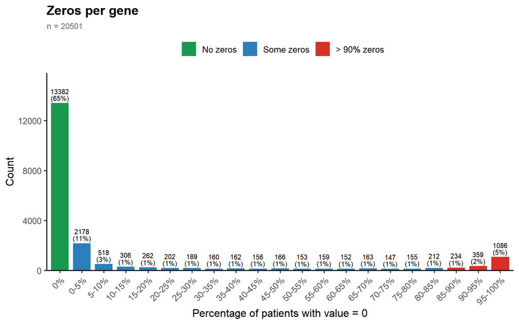

```r
plot_zero_bins(zero_gene, "Zeros per gene", "Percentage of patients with value = 0")
```

## 5.2 Zeros per patient

All patients should have a similar proportion of zeros. A patient with many more zeros than the rest would suggest a sample with a global detection problem (e.g. low sequencing quality).

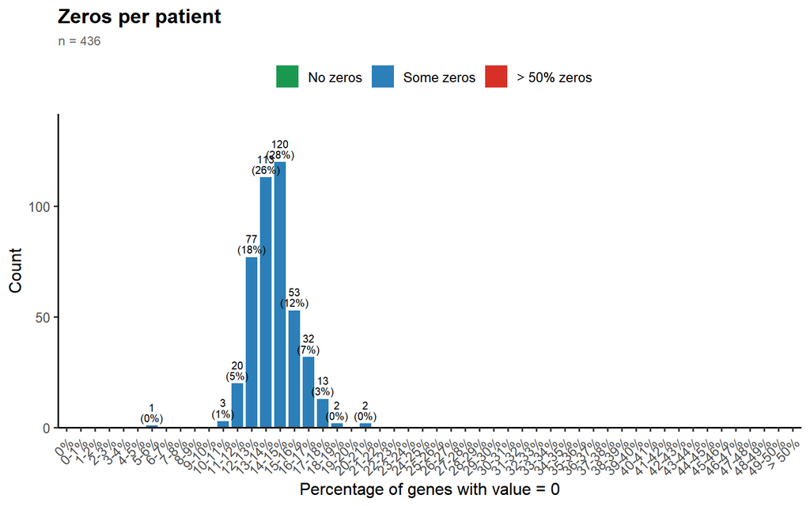

```r
plot_zero_bins(zero_sample, "Zeros per patient", "Percentage of genes with value = 0",
               step = 0.01, max_frac = 0.5)
```

## 5.3 Expression level of detected values

The **mean of the non-zero values** of each gene tells how strongly a gene is expressed *when it is detected*. If the distribution is bimodal, the low component is mostly detection noise and the high component the clearly expressed genes. Genes with low expression and frequent zeros are removed (see Filtering below).

```r
nz_mean <- apply(X, 2, function(x) if (any(x > 0)) mean(x[x > 0]) else 0)

# Data-driven threshold: minimum of the density between 1 and 7.
d      <- density(nz_mean)
search <- d$x > 1 & d$x < 7
nz_cut <- round(d$x[search][which.min(d$y[search])], 2)
nz_cut
```

[output not shown]

## 5.4 Filtering

Genes are removed if they carry no information or if they look like detection noise:

| Rule | Criterion | Rationale |
| --- | --- | --- |
| Zero variance | SD = 0 | No information at all |
| Mostly zeros | zeros in > 90% of patients | Not expressed |
| Low expression **and** frequent zeros | non-zero mean below a data-derived threshold (minimum of the density of the non-zero means between 1 and 7 log2 CPM + 1) **and** zeros in ≥ 10% of patients | Typical pattern of detection noise |

Genes with low but **consistent** expression (below the threshold but detected in more than 90% of patients) are **kept**: a stable low signal is unlikely to be noise. No filter on variance is applied at this step: there is no natural cut-off, and the least variable genes are usually well-expressed, stable genes rather than noise.

```r
gene_sd      <- colSds(X)
rm_zero_var  <- gene_sd == 0
rm_high_zero <- zero_gene > 0.9
rm_low_expr  <- nz_mean < nz_cut & zero_gene >= 0.1
remove       <- rm_zero_var | rm_high_zero | rm_low_expr

# Record of removed genes and the reason
filter_log <- data.frame(gene = colnames(X), nz_mean = nz_mean, zero_prop = zero_gene,
                         zero_var = rm_zero_var, high_zero = rm_high_zero,
                         low_expr = rm_low_expr, removed = remove)

X_filt <- X[, !remove]

data.frame(rule  = c("Zero variance", "Zeros in > 90% of patients",
                     "Low expression and frequent zeros", "Total removed (union)",
                     "Genes kept"),
           genes = c(sum(rm_zero_var), sum(rm_high_zero), sum(rm_low_expr),
                     sum(remove), ncol(X_filt)))
```

| rule | genes |
| --- | --- |
| Zero variance | 333 |
| Zeros in > 90% of patients | 1445 |
| Low expression and frequent zeros | 4423 |
| Total removed (union) | 4423 |
| Genes kept | 16078 |

# 6 Per-patient distributions

After normalisation, all patients should have similar distributions. A patient whose median or spread is far from the rest (|robust z| > 3) is flagged (red).

```r
sample_stats <- data.frame(sample        = rownames(X_filt),
                           sample_median = rowMedians(X_filt),
                           iqr           = rowIQRs(X_filt))
sample_stats$z_median <- robust_z(sample_stats$sample_median)
sample_stats$z_iqr    <- robust_z(sample_stats$iqr)
sample_stats$flag     <- abs(sample_stats$z_median) > 3 | abs(sample_stats$z_iqr) > 3

long <- data.frame(sample = rep(rownames(X_filt), times = ncol(X_filt)),
                   value  = as.vector(X_filt))
long$sample <- factor(long$sample,
                      levels = sample_stats$sample[order(sample_stats$sample_median)])
long$flag   <- sample_stats$flag[match(long$sample, sample_stats$sample)]
```

## 6.1 Boxplot per patient

Patients are ordered by their median. Well-aligned boxes indicate a good normalisation.

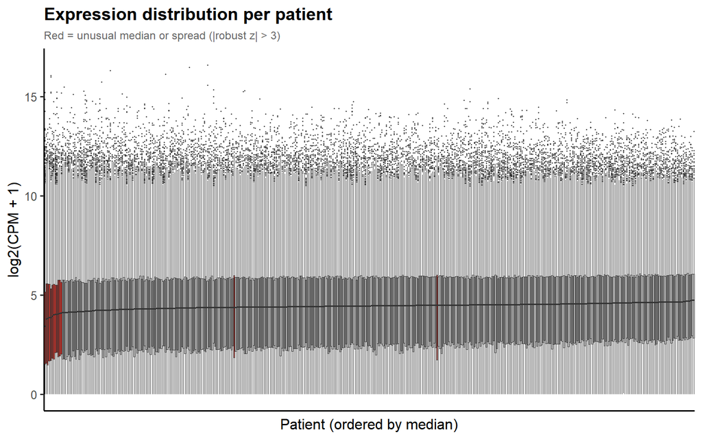

```r
ggplot(long, aes(sample, value, fill = flag)) +
  geom_boxplot(outlier.size = 0.2, linewidth = 0.3) +
  scale_fill_manual(values = c(`FALSE` = "grey80", `TRUE` = "#D73027"), guide = "none") +
  labs(title = "Expression distribution per patient",
       subtitle = "Red = unusual median or spread (|robust z| > 3)",
       x = "Patient (ordered by median)", y = "log2(CPM + 1)") +
  theme_qc() +
  theme(axis.text.x = element_blank(), axis.ticks.x = element_blank())
```

## 6.2 Density per patient

Each line is one patient. A curve with a different shape or clearly shifted would point to a technical problem in that sample.

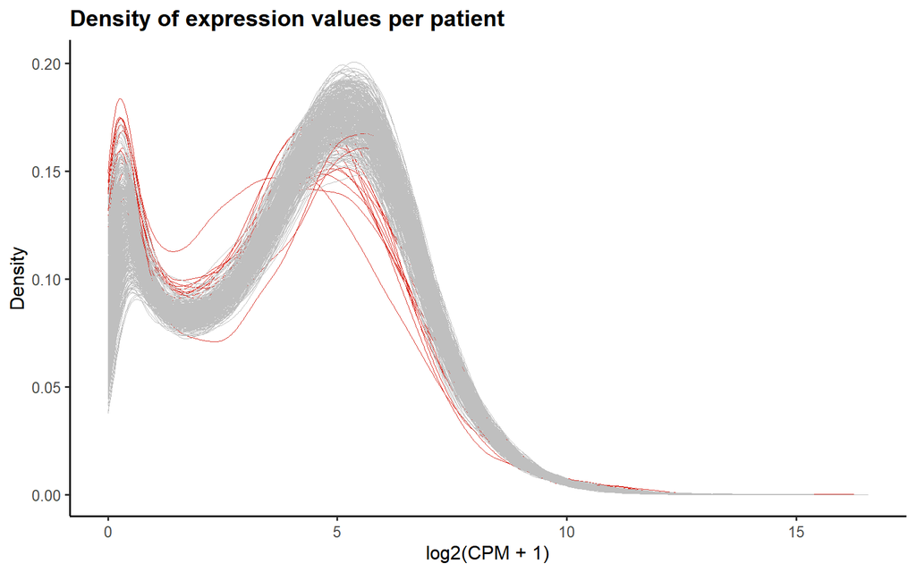

```r
ggplot(long, aes(value, group = sample, colour = flag)) +
  geom_density(linewidth = 0.3) +
  scale_colour_manual(values = c(`FALSE` = "grey75", `TRUE` = "#D73027"), guide = "none") +
  labs(title = "Density of expression values per patient",
       x = "log2(CPM + 1)", y = "Density") +
  theme_qc()
```

```r
subset(sample_stats, flag)
```

|  | sample | sample_median | iqr | z_median | z_iqr | flag |
| --- | --- | --- | --- | --- | --- | --- |
| TCGA-B6-A0RL | TCGA-B6-A0RL | 4.485396 | 4.276575 | 0.3001786 | 3.6629839 | TRUE |
| TCGA-E2-A9RU | TCGA-E2-A9RU | 4.004129 | 3.783174 | -3.7176183 | 1.4029186 | TRUE |
| TCGA-A2-A4S1 | TCGA-A2-A4S1 | 3.867459 | 3.623262 | -4.8585951 | 0.6704315 | TRUE |
| TCGA-LL-A6FR | TCGA-LL-A6FR | 3.922050 | 3.671932 | -4.4028504 | 0.8933678 | TRUE |
| TCGA-LL-A9Q3 | TCGA-LL-A9Q3 | 4.078402 | 3.816123 | -3.0975631 | 1.5538477 | TRUE |
| TCGA-BH-A208 | TCGA-BH-A208 | 4.032127 | 3.386773 | -3.4838839 | -0.4128269 | TRUE |
| TCGA-E2-A572 | TCGA-E2-A572 | 3.785976 | 4.021882 | -5.5388495 | 2.4963402 | TRUE |
| TCGA-LL-A6FQ | TCGA-LL-A6FQ | 3.854417 | 3.867256 | -4.9674739 | 1.7880644 | TRUE |
| TCGA-5T-A9QA | TCGA-5T-A9QA | 4.378758 | 4.145575 | -0.5900720 | 3.0629288 | TRUE |
| TCGA-AC-A2QJ | TCGA-AC-A2QJ | 3.416145 | 3.649347 | -8.6263442 | 0.7899160 | TRUE |
| TCGA-BH-A1FM | TCGA-BH-A1FM | 4.058234 | 3.862508 | -3.2659335 | 1.7663162 | TRUE |
| TCGA-A2-A3XU | TCGA-A2-A3XU | 3.819200 | 4.083716 | -5.2614845 | 2.7795760 | TRUE |
| TCGA-LL-A7SZ | TCGA-LL-A7SZ | 4.082930 | 3.614113 | -3.0597569 | 0.6285228 | TRUE |
| TCGA-E9-A3X8 | TCGA-E9-A3X8 | 4.015898 | 3.408638 | -3.6193692 | -0.3126722 | TRUE |

```r
rm(long); gc()
```

```
##            used  (Mb) gc trigger   (Mb)  max used   (Mb)
## Ncells  1648788  88.1    2739818  146.4   2739818  146.4
## Vcells 50313507 383.9  170498001 1300.8 170494943 1300.8
```

Patients flagged by their distribution (if any) are listed above. A flag here is not a reason to remove a patient, but to look at it again in the next steps.

# 7 Patient–patient correlation

Each pair of patients is compared through the Pearson correlation of their expression profiles. The **standardized connectivity (Z.k)** (Oldham et al., 2012) summarises how strongly each patient is connected to all others: correlations are transformed into connection strengths, ((1 + r) / 2)², summed per patient and standardised. Patients with **Z.k < −2** are weakly correlated with the rest and are candidate outliers.

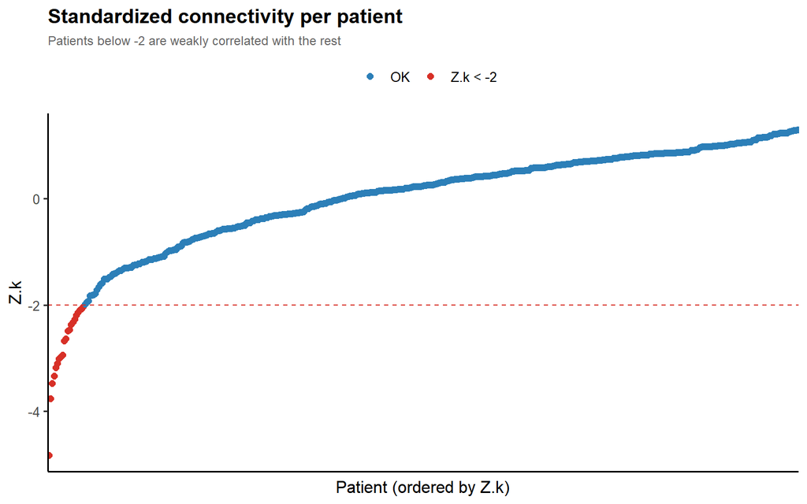

```r
C  <- cor(t(X_filt))                 # patient x patient
A  <- ((1 + C) / 2)^2
k  <- rowSums(A) - 1
zk <- (k - mean(k)) / sd(k)
med_cor <- apply(C, 1, function(x) median(x[x < 1]))

cor_stats <- data.frame(sample = rownames(X_filt), med_cor = med_cor, zk = zk)
cor_stats$group  <- ifelse(cor_stats$zk < -2, "Z.k < -2", "OK")
cor_stats$sample <- factor(cor_stats$sample, levels = cor_stats$sample[order(cor_stats$zk)])

ggplot(cor_stats, aes(sample, zk, colour = group)) +
  geom_point(size = 2) +
  geom_hline(yintercept = -2, linetype = 2, colour = "#D73027") +
  scale_colour_manual(values = c("OK" = "#2C7FB8", "Z.k < -2" = "#D73027"), name = NULL) +
  labs(title = "Standardized connectivity per patient",
       subtitle = "Patients below -2 are weakly correlated with the rest",
       x = "Patient (ordered by Z.k)", y = "Z.k") +
  theme_qc() +
  theme(axis.text.x = element_blank(), axis.ticks.x = element_blank())
```

```r
summary(med_cor)
```

```
##    Min. 1st Qu.  Median    Mean 3rd Qu.    Max.
##  0.7411  0.8570  0.8777  0.8698  0.8901  0.9044
```

```r
subset(cor_stats, zk < -2, select = c(sample, med_cor, zk))
```

|  | sample | med_cor | zk |
| --- | --- | --- | --- |
| TCGA-B6-A0RL | TCGA-B6-A0RL | 0.8131739 | -2.187723 |
| TCGA-AR-A0TU | TCGA-AR-A0TU | 0.8078158 | -2.093521 |
| TCGA-A1-A0SK | TCGA-A1-A0SK | 0.7695586 | -3.760126 |
| TCGA-A2-A4S1 | TCGA-A2-A4S1 | 0.7908255 | -2.944168 |
| TCGA-LL-A6FR | TCGA-LL-A6FR | 0.7822767 | -3.179154 |
| TCGA-D8-A1JM | TCGA-D8-A1JM | 0.8053050 | -2.316597 |
| TCGA-EW-A1PB | TCGA-EW-A1PB | 0.8089719 | -2.140236 |
| TCGA-AQ-A54N | TCGA-AQ-A54N | 0.7747175 | -3.477152 |
| TCGA-A7-A5ZV | TCGA-A7-A5ZV | 0.7954681 | -2.679226 |
| TCGA-E2-A1LK | TCGA-E2-A1LK | 0.7967654 | -2.491630 |
| TCGA-E2-A572 | TCGA-E2-A572 | 0.7817459 | -3.342348 |
| TCGA-AC-A62X | TCGA-AC-A62X | 0.8113064 | -2.030814 |
| TCGA-AC-A2BK | TCGA-AC-A2BK | 0.7898862 | -2.971658 |
| TCGA-WT-AB41 | TCGA-WT-AB41 | 0.8040433 | -2.368185 |
| TCGA-A2-A3XW | TCGA-A2-A3XW | 0.8088717 | -2.266676 |
| TCGA-E2-A574 | TCGA-E2-A574 | 0.7862703 | -3.008877 |
| TCGA-E9-A5FL | TCGA-E9-A5FL | 0.8015216 | -2.463718 |
| TCGA-AR-A0TP | TCGA-AR-A0TP | 0.8137687 | -2.069438 |
| TCGA-AC-A2QJ | TCGA-AC-A2QJ | 0.7411116 | -4.827647 |
| TCGA-A2-A3XU | TCGA-A2-A3XU | 0.7847502 | -3.098244 |
| TCGA-A1-A0SO | TCGA-A1-A0SO | 0.8003807 | -2.636515 |

The typical median correlation between patients is about 0.88, and 21 patients have Z.k < −2. A low connectivity can be technical, but it can also mean that the patient belongs to a small biological subgroup: in that case the patient still has close neighbours with similar profiles, which is visible in the heatmap below.

## 7.1 Correlation heatmap

Patients are ordered by hierarchical clustering, so that similar patients are next to each other. Blocks along the diagonal are groups of similar patients; an isolated row and column with low correlation to everyone would be a suspicious sample.

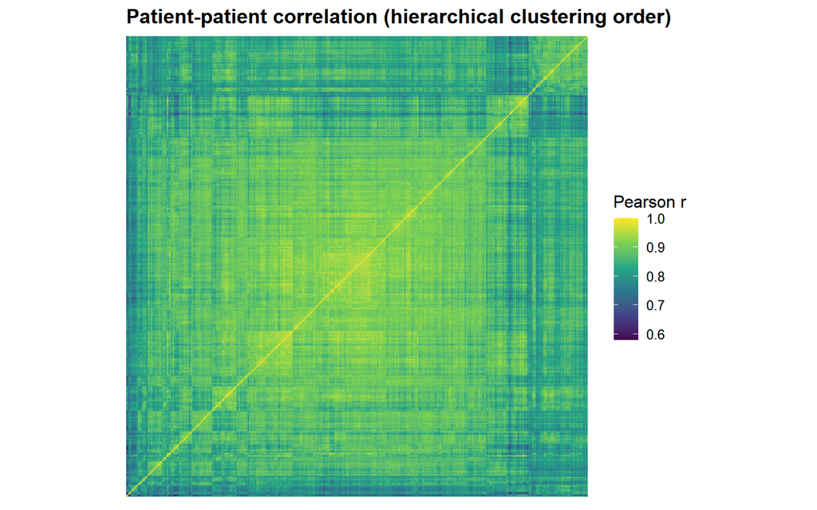

```r
hc  <- hclust(as.dist(1 - C), method = "average")
ord <- rownames(C)[hc$order]
heat_df <- data.frame(s1 = factor(rep(rownames(C), times = ncol(C)), levels = ord),
                      s2 = factor(rep(colnames(C), each = nrow(C)), levels = ord),
                      r  = as.vector(C))

ggplot(heat_df, aes(s1, s2, fill = r)) +
  geom_tile() +
  scale_fill_viridis_c(name = "Pearson r") +
  labs(title = "Patient-patient correlation (hierarchical clustering order)", x = NULL, y = NULL) +
  coord_fixed() +
  theme_minimal(base_size = 12) +
  theme(plot.title = element_text(face = "bold"),
        axis.text = element_blank(), panel.grid = element_blank())
```

```r
rm(heat_df, A); gc()
```

```
##            used  (Mb) gc trigger   (Mb)  max used   (Mb)
## Ncells  1588728  84.9    2739818  146.4   2739818  146.4
## Vcells 36048639 275.1  136398401 1040.7 170494943 1300.8
```

# 8 Gene distributions

## 8.1 Randomly selected genes

Four random genes are shown from each tertile of mean expression (low, medium, high), to see the typical shapes of the distributions at different expression levels.

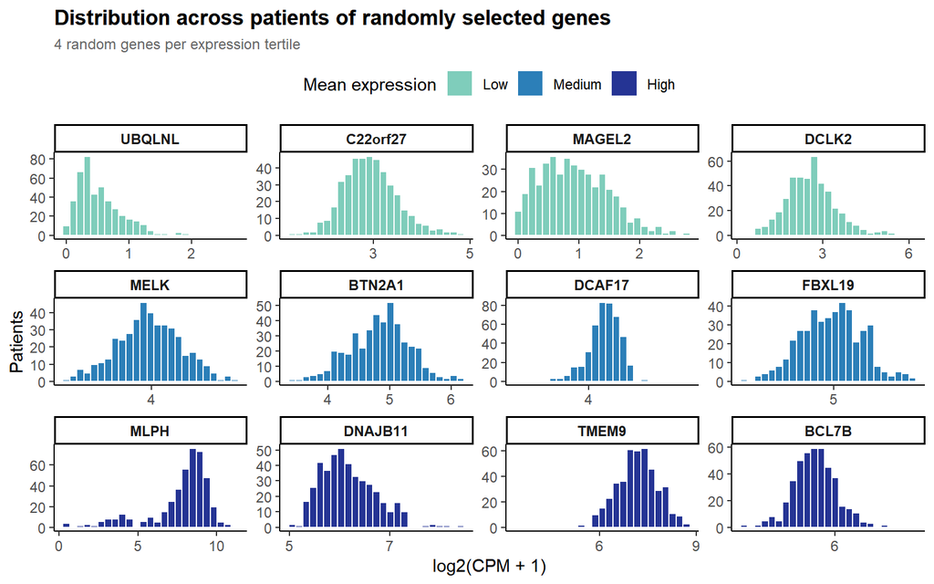

```r
set.seed(20261013)
gene_mean <- colMeans(X_filt)
strata    <- cut(gene_mean, quantile(gene_mean, c(0, 1/3, 2/3, 1)),
                 labels = c("Low", "Medium", "High"), include.lowest = TRUE)
pick <- unlist(lapply(split(colnames(X_filt), strata), sample, size = 4))

gene_df <- data.frame(gene    = factor(rep(pick, each = nrow(X_filt)), levels = pick),
                      stratum = rep(strata[match(pick, colnames(X_filt))], each = nrow(X_filt)),
                      value   = as.vector(X_filt[, pick]))

ggplot(gene_df, aes(value, fill = stratum)) +
  geom_histogram(bins = 25, colour = "white") +
  facet_wrap(~ gene, scales = "free", ncol = 4) +
  scale_x_continuous(n.breaks = 3) +
  scale_fill_manual(values = c(Low = "#7FCDBB", Medium = "#2C7FB8", High = "#253494"),
                    name = "Mean expression") +
  labs(title = "Distribution across patients of randomly selected genes",
       subtitle = "4 random genes per expression tertile",
       x = "log2(CPM + 1)", y = "Patients") +
  theme_qc(11) +
  theme(strip.text = element_text(face = "bold"))
```

## 8.2 Skewness

Skewness is reported descriptively, without classifying genes with conventional cut-offs. The red lines mark Tukey’s “far out” fences (Q1 − 3·IQR and Q3 + 3·IQR) computed on the skewness of all genes, i.e. genes that are extreme *relative to the other genes*. Skewness matters mainly for methods sensitive to tails (Pearson correlation, PCA, linear models); scaling does not change it.

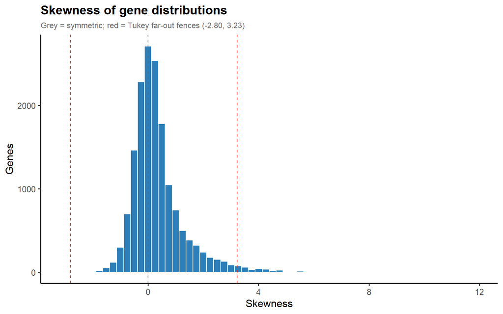

```r
gene_skew <- apply(X_filt, 2, function(x) mean((x - mean(x))^3) / sd(x)^3)
q    <- quantile(gene_skew, c(0.25, 0.75))
lims <- c(q[1] - 3 * diff(q), q[2] + 3 * diff(q))

ggplot(data.frame(skew = gene_skew), aes(skew)) +
  geom_histogram(bins = 60, fill = "#2C7FB8", colour = "white") +
  geom_vline(xintercept = 0, linetype = 2, colour = "grey40") +
  geom_vline(xintercept = lims, linetype = 2, colour = "#D73027") +
  labs(title = "Skewness of gene distributions",
       subtitle = sprintf("Grey = symmetric; red = Tukey far-out fences (%.2f, %.2f)",
                          lims[1], lims[2]),
       x = "Skewness", y = "Genes") +
  theme_qc()
```

```r
head(round(sort(gene_skew[gene_skew < lims[1] | gene_skew > lims[2]]), 2), 30)
```

```
##    CSTF2T     BET1L     BARX1     MYO3A   CLEC18A   CYP19A1   FAM179A    MCF2L2      RORB     NOTUM     STK33
##     -2.92     -2.87      3.24      3.24      3.25      3.25      3.25      3.26      3.26      3.26      3.27
##      BDNF C14orf162   CCDC141     PEX5L      CRB1      UCA1    SLC8A3    TREML2      ACE2    UNC13A     HOXB8
##      3.28      3.28      3.29      3.29      3.29      3.30      3.30      3.30      3.31      3.31      3.32
##  SLC7A5P2      BNC1   PHYHIPL       DDN     APOA1      NEFM     NDST3     SNX32
##      3.32      3.32      3.32      3.32      3.33      3.33      3.33      3.33
```

# 9 Gene–gene correlation

A correlation matrix with all genes would need several GB of memory, so the **2,000 most variable genes** are used. To judge whether the observed correlations exceed what is expected by chance, a **permutation null** is built: each gene is shuffled independently across patients, which keeps every gene’s distribution but breaks all gene–gene relationships. The 95th percentile of the null gives the chance level (red dashed line). Two views are shown:

- **All gene pairs**: the overall correlation structure.
- **Strongest correlation of each gene**: redundancy, i.e. how many genes have at least one highly correlated partner. Its chance level is higher, because the best of many candidates is always relatively high by chance.

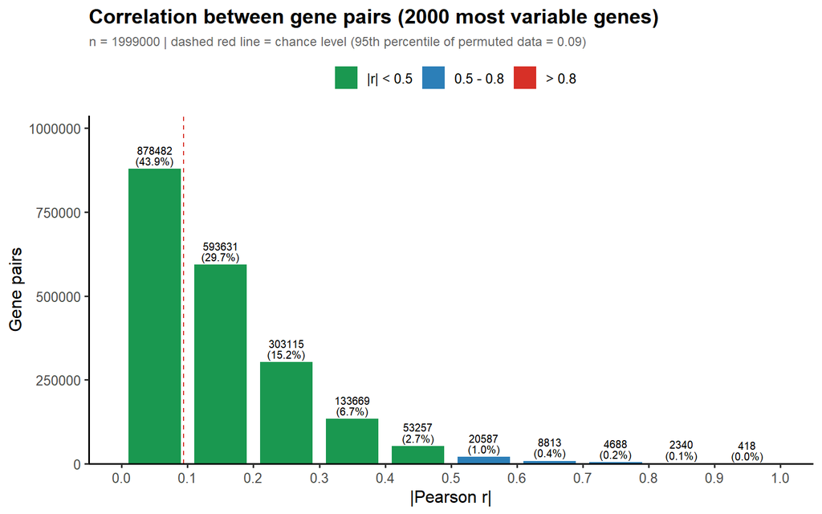

```r
n_top     <- 2000
top_genes <- colnames(X_filt)[order(colVars(X_filt), decreasing = TRUE)[1:n_top]]
Xg        <- X_filt[, top_genes]

Cg <- cor(Xg)
r_pairs <- abs(Cg[upper.tri(Cg)])
diag(Cg) <- NA
max_r <- apply(abs(Cg), 1, max, na.rm = TRUE)

set.seed(1)
X_perm <- apply(Xg, 2, sample)
Cp <- cor(X_perm)
r_pairs_null <- abs(Cp[upper.tri(Cp)])
diag(Cp) <- NA
max_r_null <- apply(abs(Cp), 1, max, na.rm = TRUE)

cut_pairs <- quantile(r_pairs_null, 0.95)
cut_max   <- quantile(max_r_null, 0.95)

# Barplot of |r| in bins of 0.1, with the chance level as a dashed line
plot_cor_bins <- function(r, null_cut, title, y_lab) {
  breaks <- seq(0, 1, by = 0.1)
  df <- data.frame(mid  = head(breaks, -1) + 0.05,
                   Freq = as.vector(table(cut(r, breaks = breaks, include.lowest = TRUE))))
  df$pct   <- df$Freq / sum(df$Freq)
  df$level <- factor(ifelse(df$mid < 0.5, "|r| < 0.5", ifelse(df$mid < 0.8, "0.5 - 0.8", "> 0.8")),
                     levels = c("|r| < 0.5", "0.5 - 0.8", "> 0.8"))

  ggplot(df, aes(mid, Freq, fill = level)) +
    geom_col(width = 0.08) +
    geom_text(data = subset(df, Freq > 0),
              aes(label = sprintf("%d\n(%.1f%%)", Freq, 100 * pct)),
              vjust = -0.2, size = 2.6, lineheight = 0.85) +
    geom_vline(xintercept = null_cut, linetype = 2, colour = "#D73027") +
    scale_fill_manual(values = c("#1A9850", "#2C7FB8", "#D73027"), name = NULL, drop = FALSE) +
    scale_x_continuous(breaks = breaks, limits = c(0, 1)) +
    scale_y_continuous(expand = expansion(mult = c(0, 0.18))) +
    labs(title = title,
         subtitle = sprintf("n = %d | dashed red line = chance level (95th percentile of permuted data = %.2f)",
                            length(r), null_cut),
         x = "|Pearson r|", y = y_lab) +
    theme_qc()
}

plot_cor_bins(r_pairs, cut_pairs,
              sprintf("Correlation between gene pairs (%d most variable genes)", n_top), "Gene pairs")
```

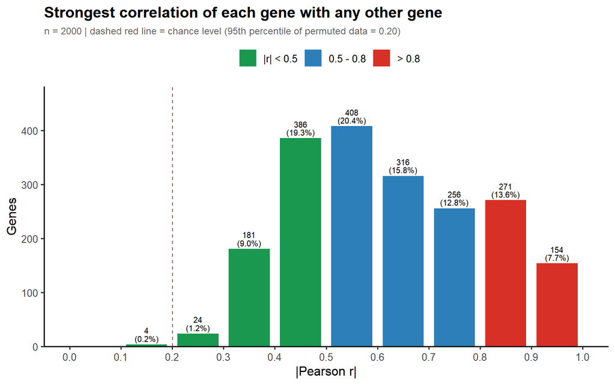

```r
plot_cor_bins(max_r, cut_max,
              "Strongest correlation of each gene with any other gene", "Genes")
```

```r
# Summary: proportion above chance and theoretical chance level 1.96 / sqrt(n - 3)
data.frame(measure = c("% gene pairs above chance level",
                       "% genes with a partner above chance level",
                       "Chance level (permutation)", "Chance level (theoretical)"),
           value   = round(c(100 * mean(r_pairs > cut_pairs), 100 * mean(max_r > cut_max),
                             cut_pairs, 1.96 / sqrt(nrow(Xg) - 3)), 3))
```

| measure | value |
| --- | --- |
| % gene pairs above chance level | 58.370 |
| % genes with a partner above chance level | 99.800 |
| Chance level (permutation) | 0.094 |
| Chance level (theoretical) | 0.094 |

```r
# Most correlated gene pairs
top_pairs <- which(abs(Cg) > 0.9 & upper.tri(Cg), arr.ind = TRUE)
head(data.frame(gene1 = rownames(Cg)[top_pairs[, 1]],
                gene2 = colnames(Cg)[top_pairs[, 2]],
                r     = round(Cg[top_pairs], 3)), 20)
```

| gene1 | gene2 | r |
| --- | --- | --- |
| SCGB2A2 | SCGB1D2 | 0.944 |
| ADIPOQ | ADH1B | 0.951 |
| ADIPOQ | FABP4 | 0.921 |
| ADH1B | FABP4 | 0.925 |
| S100A9 | S100A8 | 0.922 |
| ADAM6 | LOC96610 | 0.902 |
| ADIPOQ | PLIN1 | 0.951 |
| ADH1B | PLIN1 | 0.922 |
| FABP4 | PLIN1 | 0.912 |
| PLIN4 | PLIN1 | 0.914 |
| ADIPOQ | GPD1 | 0.941 |
| ADH1B | GPD1 | 0.905 |
| FABP4 | GPD1 | 0.908 |
| PLIN4 | GPD1 | 0.915 |
| PLIN1 | GPD1 | 0.953 |
| SAA1 | SAA2 | 0.915 |
| ADIPOQ | CIDEC | 0.932 |
| ADH1B | CIDEC | 0.901 |
| FABP4 | CIDEC | 0.908 |
| PLIN1 | CIDEC | 0.949 |

```r
rm(Cg, Cp, X_perm, Xg); gc()
```

```
##            used  (Mb) gc trigger  (Mb)  max used   (Mb)
## Ncells  1647458  88.0    2739818 146.4   2739818  146.4
## Vcells 32971562 251.6  109118721 832.6 170494943 1300.8
```

- **58.4%** of the gene pairs are more correlated than expected by chance (5% would be expected without any structure).
- **99.8%** of the genes have at least one partner more correlated than expected by chance.
- Pairs with |r| > 0.9 (listed above) are highly redundant; a small number is normal.

A widespread but mostly moderate correlation structure means that collinearity is not a major problem for the models, although methods that reduce dimensionality (PCA, penalised regression) are still preferred.

# 10 Extreme values per patient

A patient may look normal globally but have extreme values in many genes. For each gene, a robust z-score is computed; values with **|robust z| > 5** are considered extreme (under normality, essentially none would be expected in the whole matrix). The number of extreme values per patient is compared with a Tukey far-out fence (Q3 + 3·IQR). Extreme expression can be biological (e.g. gene amplifications or deletions in the tumour), so these values are **flagged, not removed**.

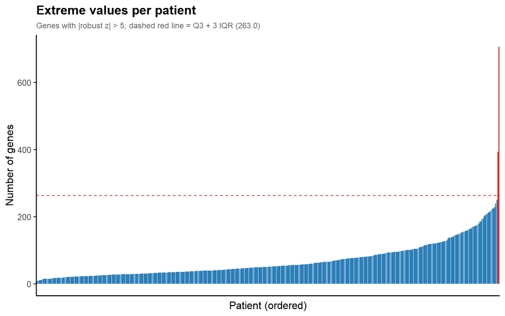

```r
med <- colMedians(X_filt)
mdv <- colMads(X_filt)
ok  <- mdv > 0                      # genes with MAD = 0 cannot be standardised
Z   <- sweep(sweep(X_filt[, ok], 2, med[ok]), 2, mdv[ok], "/")

extreme   <- abs(Z) > 5
n_extreme <- rowSums(extreme)
q         <- quantile(n_extreme, c(0.25, 0.75))
fence     <- q[2] + 3 * diff(q)

ext_df <- data.frame(sample = names(n_extreme), n = n_extreme)
ext_df$sample <- factor(ext_df$sample, levels = ext_df$sample[order(ext_df$n)])
ext_df$flag   <- ext_df$n > fence

ggplot(ext_df, aes(sample, n, fill = flag)) +
  geom_col() +
  geom_hline(yintercept = fence, linetype = 2, colour = "#D73027") +
  scale_fill_manual(values = c(`FALSE` = "#2C7FB8", `TRUE` = "#D73027"), guide = "none") +
  labs(title = "Extreme values per patient",
       subtitle = sprintf("Genes with |robust z| > 5; dashed red line = Q3 + 3 IQR (%.1f)", fence),
       x = "Patient (ordered)", y = "Number of genes") +
  theme_qc() +
  theme(axis.text.x = element_blank(), axis.ticks.x = element_blank())
```

```r
flagged_ext <- as.character(ext_df$sample[ext_df$flag])
data.frame(patient   = flagged_ext,
           n_extreme = n_extreme[flagged_ext],
           row.names = NULL)
```

| patient | n_extreme |
| --- | --- |
| TCGA-A1-A0SK | 393 |
| TCGA-AC-A2QJ | 706 |

```r
# Overall proportion of extreme values
c(n_extreme_values = sum(extreme), pct = round(100 * mean(extreme), 3))
```

```
## n_extreme_values              pct
##        29879.000            0.426
```

```r
rm(Z, extreme); gc()
```

```
##            used  (Mb) gc trigger  (Mb)  max used   (Mb)
## Ncells  1591617  85.1    2739818 146.4   2739818  146.4
## Vcells 32832280 250.5  109118721 832.6 170494943 1300.8
```

# 11 Principal component analysis

The PCA is computed on the filtered genes, **centred but not scaled**: all genes are on the same log2(CPM + 1) scale, so the most variable genes (where most of the signal lies) carry more weight.

```r
pca     <- prcomp(X_filt, center = TRUE, scale. = FALSE)
var_exp <- pca$sdev^2 / sum(pca$sdev^2)
```

## 11.1 Variance explained

Proportion of the total variance captured by each of the first 15 components.

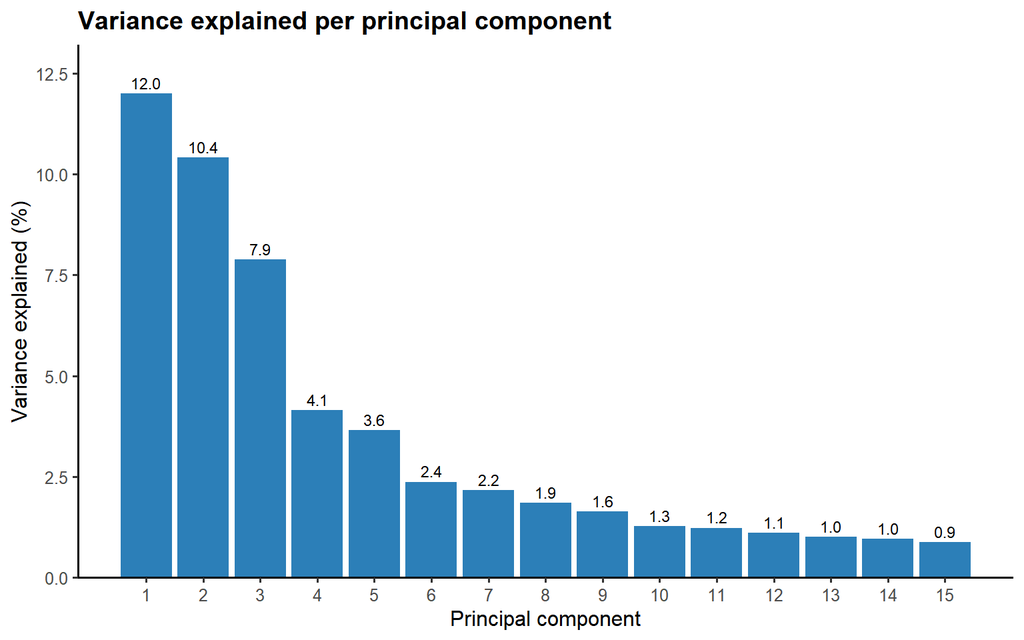

```r
ggplot(data.frame(pc = 1:15, var = 100 * var_exp[1:15]), aes(pc, var)) +
  geom_col(fill = "#2C7FB8") +
  geom_text(aes(label = sprintf("%.1f", var)), vjust = -0.4, size = 3) +
  scale_x_continuous(breaks = 1:15) +
  scale_y_continuous(expand = expansion(mult = c(0, 0.1))) +
  labs(title = "Variance explained per principal component",
       x = "Principal component", y = "Variance explained (%)") +
  theme_qc()
```

## 11.2 Data for the PCA plots

The PC scores are combined with the QC metrics of the previous sections (sample median, proportion of zeros, connectivity, number of extreme values), the tissue source site (centre, characters 6–7 of the TCGA barcode) and the outcome, to see what the main components are associated with. Patients flagged in previous steps are circled in red.

```r
pca_df <- data.frame(sample        = rownames(X_filt),
                     PC1 = pca$x[, 1], PC2 = pca$x[, 2], PC3 = pca$x[, 3],
                     sample_median = sample_stats$sample_median[match(rownames(X_filt), sample_stats$sample)],
                     zeros         = rowMeans(X_filt == 0),
                     zk            = zk[rownames(X_filt)],
                     n_extreme     = n_extreme[rownames(X_filt)],
                     centre        = substr(rownames(X_filt), 6, 7),   # tissue source site
                     stage         = clin[rownames(X_filt), "outcome_p.stage"])
pca_df$flag <- pca_df$zk < -2 | pca_df$n_extreme > fence

# Helper: PCA scatter coloured by any variable (red circles = flagged patients)
plot_pca_by <- function(df, var, x = "PC1", y = "PC2") {
  p <- ggplot(df, aes(.data[[x]], .data[[y]], colour = .data[[var]])) +
    geom_point(size = 2.3, alpha = 0.85) +
    geom_point(data = subset(df, flag), shape = 21, size = 4.3,
               colour = "#D73027", stroke = 1) +
    labs(title = sprintf("PCA coloured by %s", var),
         subtitle = "Red circles = patients flagged in previous steps",
         x = sprintf("%s (%.1f%%)", x, 100 * var_exp[as.integer(sub("PC", "", x))]),
         y = sprintf("%s (%.1f%%)", y, 100 * var_exp[as.integer(sub("PC", "", y))]),
         colour = var) +
    theme_qc()
  if (is.numeric(df[[var]])) p + scale_colour_viridis_c() else p
}
```

## 11.3 Stage and main genes of the components

The PCA coloured by pathological stage shows whether the main sources of variation in the expression data are related to the outcome. The table lists the 10 genes with the largest absolute loadings in the first three components, i.e. the genes that drive them.

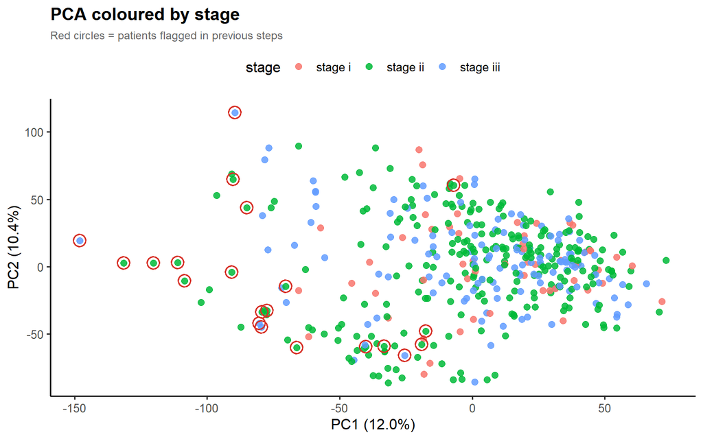

```r
plot_pca_by(pca_df, "stage")                              # outcome
```

```r
# Top 10 genes (absolute loadings) of the first three components
top_load <- function(pc, n = 10) {
  l <- pca$rotation[, pc]
  names(l[order(-abs(l))][1:n])
}
data.frame(PC1 = top_load(1), PC2 = top_load(2), PC3 = top_load(3))
```

| PC1 | PC2 | PC3 |
| --- | --- | --- |
| IL6ST | TFF3 | ADH1B |
| ESR1 | TFF1 | DARC |
| PGR | AGR3 | FABP4 |
| GFRA1 | ESR1 | C7 |
| SCUBE2 | AGR2 | LTF |
| AR | MLPH | ADIPOQ |
| FOXA1 | CYP2B7P1 | KRT14 |
| AGR3 | DEGS2 | CCL19 |
| ERBB4 | SCUBE2 | IGJ |
| AFF3 | KIF12 | MFAP4 |

## 11.4 Association with QC metrics and centre

Spearman correlations between the first five components and the QC metrics: a strong correlation with a QC metric would indicate that a component captures a technical effect. The Kruskal–Wallis test checks whether the components differ between tissue source sites (centres with at least 3 patients), which would indicate a **centre (batch) effect**.

```r
n_pc <- 5
round(cor(pca$x[, 1:n_pc],
          pca_df[, c("sample_median", "zeros", "zk", "n_extreme")],
          method = "spearman"), 2)
```

```
##     sample_median zeros    zk n_extreme
## PC1          0.25 -0.35  0.54     -0.55
## PC2          0.07  0.08  0.15     -0.25
## PC3          0.46 -0.56  0.38     -0.30
## PC4         -0.17  0.09  0.01     -0.04
## PC5          0.58 -0.16 -0.14      0.26
```

```r
# Kruskal-Wallis test of each PC by centre (centres with at least 3 patients)
big_centres <- names(which(table(pca_df$centre) >= 3))
in_big      <- pca_df$centre %in% big_centres
data.frame(PC = paste0("PC", 1:n_pc),
           p_centre = sapply(1:n_pc, function(i)
             signif(kruskal.test(pca$x[in_big, i] ~ factor(pca_df$centre[in_big]))$p.value, 2)))
```

| PC | p_centre |
| --- | --- |
| PC1 | 0.0e+00 |
| PC2 | 8.8e-04 |
| PC3 | 1.4e-05 |
| PC4 | 1.1e-01 |
| PC5 | 2.4e-03 |

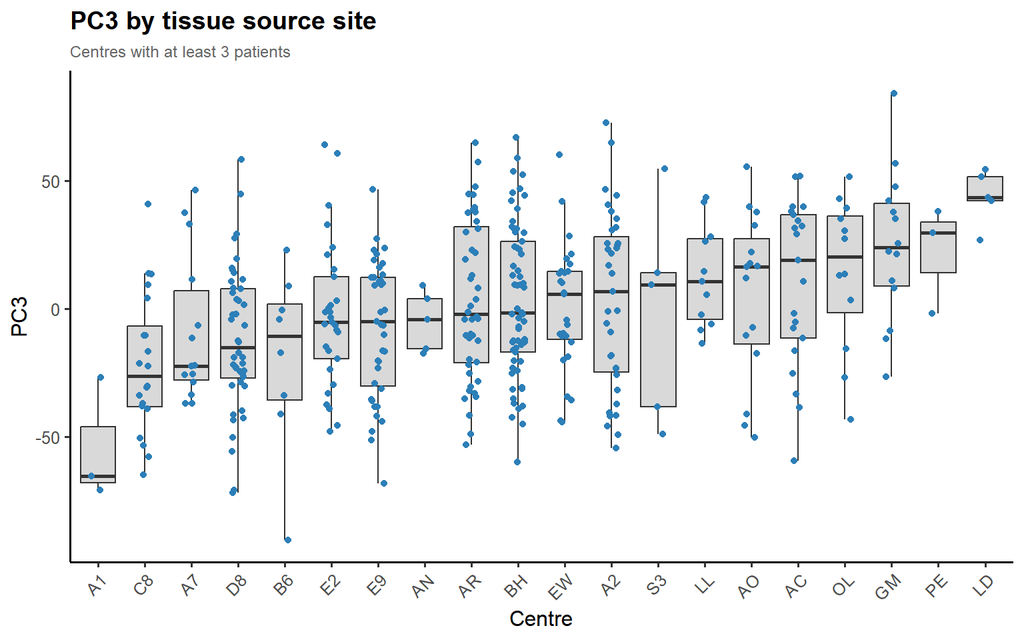

```r
ggplot(subset(pca_df, in_big), aes(reorder(centre, PC3, FUN = stats::median), PC3)) +
  geom_boxplot(fill = "grey85", outlier.shape = NA) +
  geom_jitter(width = 0.15, size = 1.5, colour = "#2C7FB8") +
  labs(title = "PC3 by tissue source site",
       subtitle = "Centres with at least 3 patients",
       x = "Centre", y = "PC3") +
  theme_qc() +
  theme(axis.text.x = element_text(angle = 45, hjust = 1))
```

## 11.5 Sensitivity to the most atypical patient

The PCA is repeated without the patient with the lowest connectivity. If the loadings with and without this patient are almost identical (absolute correlations close to 1; the sign of a component is arbitrary), this patient does not drive the PCA.

```r
most_atypical <- names(which.min(zk))
most_atypical
```

```
## [1] "TCGA-AC-A2QJ"
```

```r
pca_wo <- prcomp(X_filt[rownames(X_filt) != most_atypical, ], center = TRUE, scale. = FALSE)
data.frame(PC = paste0("PC", 1:n_pc),
           abs_cor_loadings = round(abs(diag(cor(pca$rotation[, 1:n_pc],
                                                 pca_wo$rotation[, 1:n_pc]))), 3))
```

|  | PC | abs_cor_loadings |
| --- | --- | --- |
| PC1 | PC1 | 0.998 |
| PC2 | PC2 | 0.999 |
| PC3 | PC3 | 0.999 |
| PC4 | PC4 | 0.999 |
| PC5 | PC5 | 0.996 |

```r
rm(pca_wo); gc()
```

```
##            used  (Mb) gc trigger  (Mb)  max used   (Mb)
## Ncells  1577855  84.3    2739818 146.4   2739818  146.4
## Vcells 32775791 250.1  109118721 832.6 170494943 1300.8
```

# 12 QC summary per patient

Patients flagged in at least one step (distribution, connectivity, extreme values). They are **flagged, not removed**: downstream analyses can be repeated with and without them.

```r
qc_table <- data.frame(
  patient           = rownames(X_filt),
  flag_distribution = sample_stats$flag[match(rownames(X_filt), sample_stats$sample)],
  flag_connectivity = zk[rownames(X_filt)] < -2,
  flag_extreme      = n_extreme[rownames(X_filt)] > fence
)
qc_table$n_flags <- rowSums(qc_table[, -1])
qc_flagged <- qc_table[qc_table$n_flags > 0, ]
qc_flagged[order(-qc_flagged$n_flags), ]
```

|  | patient | flag_distribution | flag_connectivity | flag_extreme | n_flags |
| --- | --- | --- | --- | --- | --- |
| TCGA-AC-A2QJ | TCGA-AC-A2QJ | TRUE | TRUE | TRUE | 3 |
| TCGA-B6-A0RL | TCGA-B6-A0RL | TRUE | TRUE | FALSE | 2 |
| TCGA-A1-A0SK | TCGA-A1-A0SK | FALSE | TRUE | TRUE | 2 |
| TCGA-A2-A4S1 | TCGA-A2-A4S1 | TRUE | TRUE | FALSE | 2 |
| TCGA-LL-A6FR | TCGA-LL-A6FR | TRUE | TRUE | FALSE | 2 |
| TCGA-E2-A572 | TCGA-E2-A572 | TRUE | TRUE | FALSE | 2 |
| TCGA-A2-A3XU | TCGA-A2-A3XU | TRUE | TRUE | FALSE | 2 |
| TCGA-AR-A0TU | TCGA-AR-A0TU | FALSE | TRUE | FALSE | 1 |
| TCGA-E2-A9RU | TCGA-E2-A9RU | TRUE | FALSE | FALSE | 1 |
| TCGA-LL-A9Q3 | TCGA-LL-A9Q3 | TRUE | FALSE | FALSE | 1 |
| TCGA-D8-A1JM | TCGA-D8-A1JM | FALSE | TRUE | FALSE | 1 |
| TCGA-EW-A1PB | TCGA-EW-A1PB | FALSE | TRUE | FALSE | 1 |
| TCGA-AQ-A54N | TCGA-AQ-A54N | FALSE | TRUE | FALSE | 1 |
| TCGA-A7-A5ZV | TCGA-A7-A5ZV | FALSE | TRUE | FALSE | 1 |
| TCGA-E2-A1LK | TCGA-E2-A1LK | FALSE | TRUE | FALSE | 1 |
| TCGA-BH-A208 | TCGA-BH-A208 | TRUE | FALSE | FALSE | 1 |
| TCGA-LL-A6FQ | TCGA-LL-A6FQ | TRUE | FALSE | FALSE | 1 |
| TCGA-AC-A62X | TCGA-AC-A62X | FALSE | TRUE | FALSE | 1 |
| TCGA-AC-A2BK | TCGA-AC-A2BK | FALSE | TRUE | FALSE | 1 |
| TCGA-WT-AB41 | TCGA-WT-AB41 | FALSE | TRUE | FALSE | 1 |
| TCGA-A2-A3XW | TCGA-A2-A3XW | FALSE | TRUE | FALSE | 1 |
| TCGA-E2-A574 | TCGA-E2-A574 | FALSE | TRUE | FALSE | 1 |
| TCGA-E9-A5FL | TCGA-E9-A5FL | FALSE | TRUE | FALSE | 1 |
| TCGA-5T-A9QA | TCGA-5T-A9QA | TRUE | FALSE | FALSE | 1 |
| TCGA-AR-A0TP | TCGA-AR-A0TP | FALSE | TRUE | FALSE | 1 |
| TCGA-BH-A1FM | TCGA-BH-A1FM | TRUE | FALSE | FALSE | 1 |
| TCGA-A1-A0SO | TCGA-A1-A0SO | FALSE | TRUE | FALSE | 1 |
| TCGA-LL-A7SZ | TCGA-LL-A7SZ | TRUE | FALSE | FALSE | 1 |
| TCGA-E9-A3X8 | TCGA-E9-A3X8 | TRUE | FALSE | FALSE | 1 |

# 13 Summary

- **4423 genes were removed** (not expressed, or low expression with frequent zeros), and **16078 genes are kept** for the models.
- **No patient was removed.** 29 patients were flagged in at least one step and are kept, as their atypical profiles can be biological.
- The PCA shows whether the main structure of the data is related to the outcome, to QC metrics or to the centre; a centre effect should be kept in mind when interpreting the models.

# 14 Save

The filtered data and the QC parameters are written by the R script `02_qc_rnaseq.R`. In this report the code is shown but **not run**, so that knitting does not overwrite the processed data (nor the model cache that depends on them). Patients are saved in rows, with a patientID column as in the other datasets.

```r
path.x <- "./data/processed"
dir.create(path.x, showWarnings = FALSE, recursive = TRUE)

rna_df <- data.frame(X_filt, check.names = FALSE)
rna_df$patientID <- rownames(rna_df)
rna_df <- rna_df[, c(ncol(rna_df), 1:(ncol(rna_df) - 1))]   # patientID as first column

saveRDS(rna_df, file.path(path.x, "rna.train.filtered.rds"))          # filtered genes, log2(CPM + 1)

# Parameters estimated on the training set, to apply the same filtering to the test set
saveRDS(list(kept_genes = colnames(X_filt),   # genes kept after filtering
             nz_cut     = nz_cut,             # threshold of the non-zero mean
             filter_log = filter_log,         # reason for removal of each gene
             qc_flagged = qc_flagged),        # patients flagged in the QC
        file.path(path.x, "rna_qc_params.rds"))

gc()
```